# DSPG 2022 Zimbabwe Remote - Soil Moisture

Susan E. Chen and Zimbabwe 2022 Team

```r
knitr::opts_chunk$set(echo = TRUE)
library(dplyr)
library(ggplot2)
library(ggrepel)
library(stringr)
library(sf)
library(tidyverse)
library(viridis)
library(zoo)
```

```r
# Read in the data from GEE. Drop some unneccesary variables and rename the region variable. Write the dataset to a dataframe
#setwd("D:/Virginia Tech/Summer 2022/Project-Zimbabwe/")
setwd("C:/Users/ecsusan/Dropbox/2021VT-DSPG-FILES/Zimbabwe/GEE_EVI/")
mydatXL2 <- read_csv("soil_ts_Zimb.csv")
mydat <- as.data.frame(mydatXL2) #TURN INTO AN R DATAFRAME

mydat <- mydat %>%
  select(nat_region, `NASA_USDA_SMAP_SM20150502_20150504_ssm`:`NASA_USDA_SMAP_SM20211229_20211231_ssm`) %>% #select needed columns--Districts and observations
  rename(region = nat_region)
```

```r
# Reshape the data from wide to long format & create number of 3 day intervals with ideal, wet, dry, and extremely dry intervals.

#Step 1: transpose
mydat_long <- gather(mydat, Date, Moisture, 'NASA_USDA_SMAP_SM20150502_20150504_ssm': 'NASA_USDA_SMAP_SM20211229_20211231_ssm') %>% select(Date, Moisture, region) %>% separate( col=Date, into=c('useless1', 'useless2','useless3','useless4','Date','useless5'), sep='_') %>% select(-useless1,-useless2,-useless3,-useless4,-useless5,)

#Read date string into an R Date Variable and remove date character variable from dataset.
mydat_long$newDate <- as.Date(mydat_long$Date, "%Y%m%d") -2
mydat_long <-mydat_long %>% select(-c(Date))
# attributes(mydat_long$newDate)

#Generate categories for soil moisture
mydat_longg <- mydat_long %>%
  mutate(
         Wet = case_when(Moisture > 25 ~ 1,
                                  TRUE ~ 0),

         Ideal = case_when(Moisture >= 15 & Moisture <=25 ~ 1,
                                  TRUE ~ 0),

         Dry = case_when(Moisture >10 & Moisture <15 ~ 1,
                                  TRUE ~ 0),

         ExtremelyDry = case_when(Moisture <=10 ~ 1,
                                  TRUE ~ 0),
         )
```

```r
# Make sure that the data is in columns for each region. This step will group by column to get the desired wide dataset.
#Put into columns by group
mydat_long2 <- transform(mydat_longg,                                 # Create ID by group
                      ID = as.numeric(factor(region))) %>% select(-c(region)) %>% reshape(idvar = "newDate",
                          timevar = "ID", direction = "wide")

# head(mydat_long2)
```

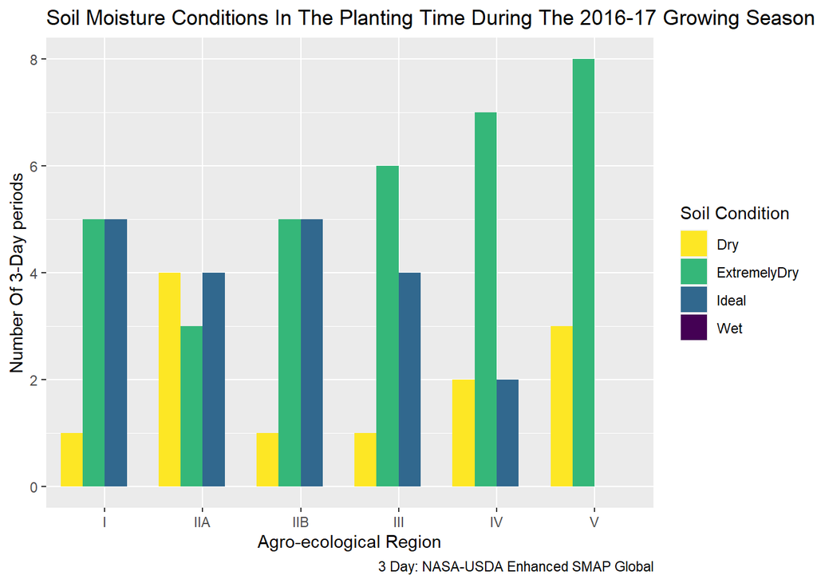

```r
# Keep only one month: Nov 19-Dec 19 2016 of the growing season and sum the data in each column for the Wet, Ideal, Dry, and Extremely Dry columns. This makes the nice side-by-side histograms for regions.

# Set axis limits c(min, max) on plot
 min <- as.Date("2016-11-19")
 max <- as.Date("2016-12-19")

sum_g1 <- mydat_longg %>%
  filter(between(mydat_longg$newDate, min, max))
sum_g1 <- sum_g1

#Summarise data like this before plotting:
library(dplyr)

df <- sum_g1 %>%  select(-c(newDate)) %>%
   group_by(region) %>%
   summarise_all(sum)  %>% select(-c(Moisture))

#Need this step to do side-by-side histogram by region
df2 <- reshape(data=df, idvar = "region",
               varying = c("Wet","Ideal","Dry","ExtremelyDry"),
               v.name=c("value"),
               times = c("Wet","Ideal","Dry","ExtremelyDry"),
               new.row.names = 1:30,
               direction=("long"))

# Grouped
 ggplot(df2, aes(fill=time, y=value, x=region)) +
     geom_bar(position="dodge", stat="identity")+
     labs(color="time") +
     xlab("Agro-ecological Region") + ylab("Number Of 3-Day periods") +
     ggtitle("Soil Moisture Conditions In The Planting Time During The 2016-17 Growing Season") +
     guides(fill=guide_legend(title="Soil Condition")) + labs(caption = "3 Day: NASA-USDA Enhanced SMAP Global") +
     scale_fill_viridis(discrete=TRUE, direction=-1)
```

```r
     #3day periods within 30 days of 11/19/16 by region and Surf-soil moisture condition
```

In this bar graph note that there are no wet days. Say this in the Shiny App.

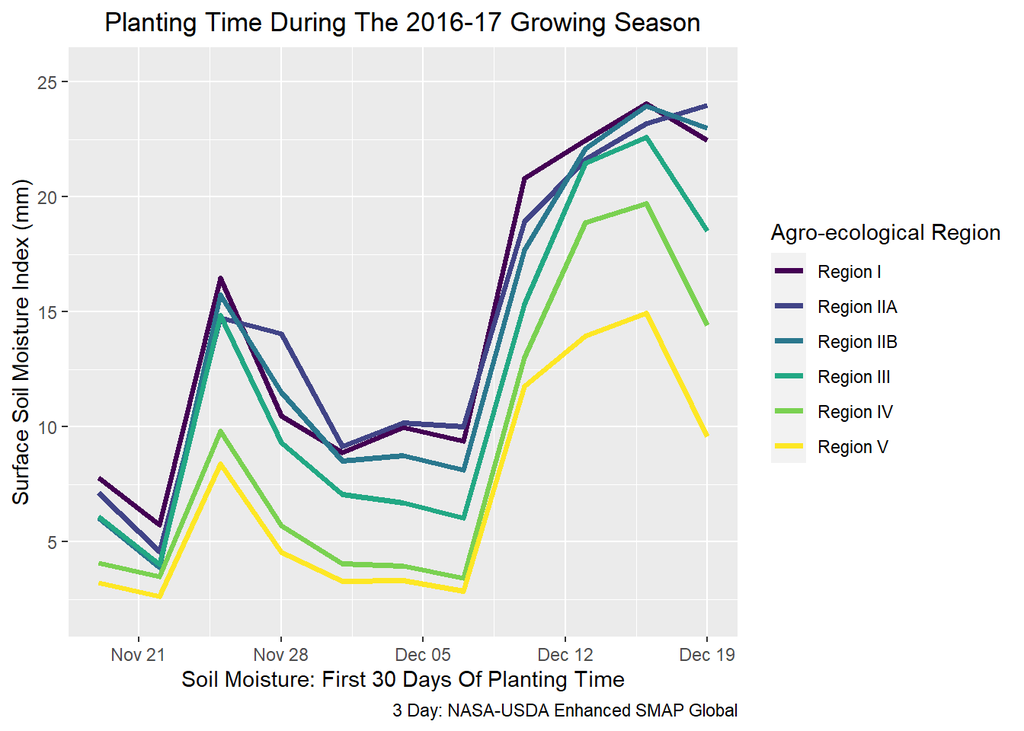

```r
# Now let us look at the first month of the growing season. This means we will subset our sample to the first 30 days of planting in the 2016-17 Growing Season. We set this with the min and max variables below.
# Set limits to first thirty days of the growing season: c(min, max)
min <- as.yearmon("20161119", "%Y%m")
max <- as.yearmon("20161219", "%Y%m")

# Set axis limits c(min, max) on plot
 min <- as.Date("2016-11-19")
 max <- as.Date("2016-12-19")

#Another plot with more regions -- add more here
p <- ggplot(mydat_long2, aes(newDate, y = value, color = variable)) +
    geom_line(aes(y = Moisture.1, col = "Region I"), size=1.25) +
    geom_line(aes(y = Moisture.2, col = "Region IIA"), size=1.25) +
    geom_line(aes(y = Moisture.3, col = "Region IIB"), size=1.25) +
    geom_line(aes(y = Moisture.4, col = "Region III"), size=1.25) +
    geom_line(aes(y = Moisture.5, col = "Region IV"), size=1.25) +
    geom_line(aes(y = Moisture.6, col = "Region V"), size=1.25) +
    labs(color="Agro-ecological Region") +
    xlab("Soil Moisture: First 30 Days Of Planting Time") + ylab("Surface Soil Moisture Index (mm)") +
    ggtitle("Planting Time During The 2016-17 Growing Season") +
    theme(plot.title = element_text(hjust = 0.5)) + scale_color_viridis(discrete = TRUE, option = "viridis") +
    scale_x_date(limits = c(min, max)) + labs(caption = "3 Day: NASA-USDA Enhanced SMAP Global")  + theme(plot.caption=element_text(hjust = 1))
p
```

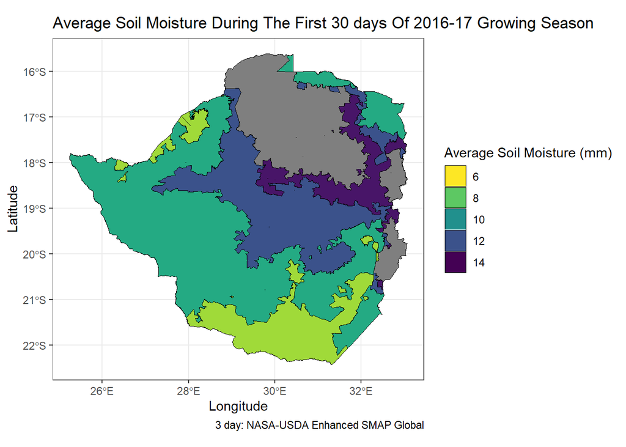

```r
#Add maps

zim_region <- st_read("./agro-ecological-regions/agro-ecological-regions.shp")
zim_region <-rename(zim_region, region = nat_region)

# attributes(mydat_long2$newDate)

 map1 <- sum_g1  %>%
   group_by(region)  %>%
   dplyr::summarize(AvgSurfaceMoisture = mean(Moisture, na.rm = TRUE))

 df_list <- list(zim_region, map1)

 #merge all data frames in list
 total <- df_list %>% reduce(full_join, by='region')

 #Get a coordinate on the surface of each region's polygon to add a region label
 # map2 <- total  %>%
 #  mutate(lon = map_dbl(geometry, ~st_point_on_surface(.x)[[1]]),
 #         lat = map_dbl(geometry, ~st_point_on_surface(.x)[[2]]))
  #
  #  ggplot() +
  #  ggplot2::geom_sf(data = map2, fill = "orange") +
  #  geom_label_repel(data = map2, aes(x = lon, y = lat, label = region))
  # #

  ggplot(data = total) +
     geom_sf(size = 0.15, color = "black", aes(fill = AvgSurfaceMoisture)) +
    xlab("Longitude") + ylab("Latitude") +
   coord_sf() +
    scale_fill_viridis(option = "viridis", direction = -1, limits=c(6,14), breaks=c(6,8,10,12,14), labels=c("6","8", "10", "12", "14")) +
     ggtitle("Average Soil Moisture During The First 30 days Of 2016-17 Growing Season") + labs(caption = "3 day: NASA-USDA Enhanced SMAP Global") +
     guides(fill=guide_legend(title="Average Soil Moisture (mm)"))+theme_bw()
```

# 1 To Do: do you want to label maps with the regions? I tried to find the centroid of each region’s polygon and save the x,y coordinates. This effort was not great as some regons are not-contiguous. The code I generated is commented out in case someone wants to try to fix it.

# 2 Settle on labels for all maps/graphs/figures - Susan & Naveen did this. Please let me know if you want to change them.

# 3 Harmonize the colors on all the visualizations so they mean the same thing. For two of the graphs we did this. For the histogram made no sense.

# 4 do we want a map of average monthly rainfall with growing season – some type of infographic as below? Do this along with main crops as in the pdf file. Like this one:

# 5 Make sure all the color schemes are the same by using the viridis package (see code above). Make sure scales are the same and the colors map across all diagrams within an indicator. Make sure all fonts/typeface are the same and clean across all indicators and all diagrams. Where do we want to put the legends? Inside the box or map – see last year. Also needs to work with leaflet??

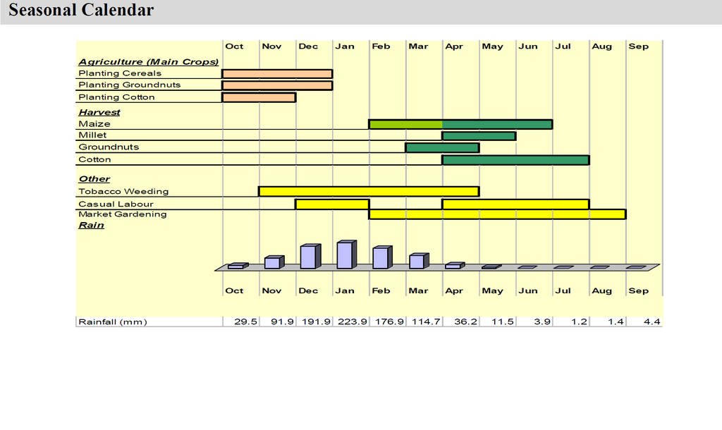